# Assignment 2:

# Task 1: Symbolic, Unconditioned Generation

##### Dataset: EMOPIA_1.0

##### Output file: symbolic_unconditioned_mid

## Setup

```python
# EMOPIA_1.0 folder should be in the same folder as this notebook before running.

from __future__ import annotations

import csv
import html
import math
import random
import re
import statistics
import struct
from collections import Counter, defaultdict
from dataclasses import dataclass
from pathlib import Path


DATASET_DIR = Path("EMOPIA_1.0")
OUTPUT_MIDI = Path("symbolic_unconditioned.mid")
OUTPUT_HTML = Path("output.html")
RANDOM_SEED = 153253

TIME_SHIFT_PREFIX = "TS_"
NOTE_PREFIX = "N_"
START = "<START>"
END = "<END>"
```

## Data Containers

The following dataclasses store parsed MIDI notes and parsed MIDI clips.

```python
@dataclass
class Note:
    start: int
    end: int
    pitch: int
    velocity: int

@dataclass
class MidiClip:
    path: Path
    ticks_per_beat: int
    notes: list[Note]
```

## MIDI low-level helpers

MIDI files store many time values as variable-length quantities, the following helper functions read and wirte that compact format.

```python
def read_vlq(data: bytes, pos: int) -> tuple[int, int]:
    value = 0
    while True:
        if pos >= len(data):
            raise ValueError("Unexpected end of data while reading variable-length integer")
        byte = data[pos]
        pos += 1
        value = (value << 7) | (byte & 0x7F)
        if not byte & 0x80:
            return value, pos


def write_vlq(value: int) -> bytes:
    if value < 0:
        raise ValueError("VLQ values must be non-negative")
    buffer = value & 0x7F
    value >>= 7
    while value:
        buffer <<= 8
        buffer |= (value & 0x7F) | 0x80
        value >>= 7
    out = bytearray()
    while True:
        out.append(buffer & 0xFF)
        if buffer & 0x80:
            buffer >>= 8
        else:
            break
    return bytes(out)
```

## MIDI Parsing

The following functions will cover functionality revolving around reading each MIDI file, walking though track events, pairing note-on/note-off events, and return a list of notes.

```python
def parse_midi(path: Path) -> MidiClip:
    data = path.read_bytes()
    pos = 0
    if data[pos : pos + 4] != b"MThd":
        raise ValueError(f"{path} is not a MIDI file")
    pos += 4
    header_length = struct.unpack(">I", data[pos : pos + 4])[0]
    pos += 4
    fmt, num_tracks, division = struct.unpack(">HHH", data[pos : pos + 6])
    pos += header_length
    if division & 0x8000:
        raise ValueError(f"{path} uses SMPTE time division, which this script does not support")

    all_notes: list[Note] = []
    for _ in range(num_tracks):
        if data[pos : pos + 4] != b"MTrk":
            raise ValueError(f"{path} has malformed track header")
        pos += 4
        track_length = struct.unpack(">I", data[pos : pos + 4])[0]
        pos += 4
        track_data = data[pos : pos + track_length]
        pos += track_length
        all_notes.extend(parse_track_notes(track_data))

    all_notes.sort(key=lambda n: (n.start, n.pitch, n.end))
    return MidiClip(path=path, ticks_per_beat=division, notes=all_notes)


def parse_track_notes(track: bytes) -> list[Note]:
    notes: list[Note] = []
    active: dict[tuple[int, int], list[tuple[int, int]]] = defaultdict(list)
    tick = 0
    pos = 0
    running_status: int | None = None

    while pos < len(track):
        delta, pos = read_vlq(track, pos)
        tick += delta
        if pos >= len(track):
            break

        status_or_data = track[pos]
        if status_or_data & 0x80:
            status = status_or_data
            pos += 1
            if status < 0xF0:
                running_status = status
        else:
            if running_status is None:
                raise ValueError("MIDI running status used before status byte")
            status = running_status

        if status == 0xFF:
            if pos >= len(track):
                break
            meta_type = track[pos]
            pos += 1
            length, pos = read_vlq(track, pos)
            pos += length
            if meta_type == 0x2F:
                break
            continue

        if status in (0xF0, 0xF7):
            length, pos = read_vlq(track, pos)
            pos += length
            continue

        event_type = status & 0xF0
        channel = status & 0x0F
        data_len = 1 if event_type in (0xC0, 0xD0) else 2
        event_data = track[pos : pos + data_len]
        pos += data_len
        if len(event_data) < data_len:
            break

        if event_type == 0x90:
            pitch, velocity = event_data[0], event_data[1]
            key = (channel, pitch)
            if velocity > 0:
                active[key].append((tick, velocity))
            elif active[key]:
                start, start_velocity = active[key].pop(0)
                if tick > start:
                    notes.append(Note(start, tick, pitch, start_velocity))
        elif event_type == 0x80:
            pitch = event_data[0]
            key = (channel, pitch)
            if active[key]:
                start, start_velocity = active[key].pop(0)
                if tick > start:
                    notes.append(Note(start, tick, pitch, start_velocity))

    return notes
```

## Tokenization

This section is responsible for converting note events into symbolic language-model tokens. Time-shift tokens advance time, and note tokens add pitches at the current time.

```python
def quantize_notes(clip: MidiClip, max_duration_steps: int = 32) -> list[tuple[int, int, int, int]]:
    step_ticks = max(1, round(clip.ticks_per_beat / 4))
    quantized = []
    for note in clip.notes:
        start_step = max(0, round(note.start / step_ticks))
        duration_steps = max(1, round((note.end - note.start) / step_ticks))
        duration_steps = min(max_duration_steps, duration_steps)
        velocity_bin = min(7, max(1, round(note.velocity / 16)))
        if 0 <= note.pitch <= 127:
            quantized.append((start_step, note.pitch, duration_steps, velocity_bin))
    quantized.sort(key=lambda n: (n[0], n[1], n[2], n[3]))
    return quantized


def clip_to_tokens(clip: MidiClip) -> list[str]:
    tokens = [START]
    current_step = 0
    for start_step, pitch, duration_steps, velocity_bin in quantize_notes(clip):
        gap = start_step - current_step
        while gap > 0:
            shift = min(16, gap)
            tokens.append(f"{TIME_SHIFT_PREFIX}{shift}")
            current_step += shift
            gap -= shift
        tokens.append(f"{NOTE_PREFIX}{pitch}_{duration_steps}_{velocity_bin}")
    tokens.append(END)
    return tokens


def parse_note_token(token: str) -> tuple[int, int, int] | None:
    if not token.startswith(NOTE_PREFIX):
        return None
    parts = token[len(NOTE_PREFIX) :].split("_")
    if len(parts) != 3:
        return None
    try:
        pitch, duration, velocity_bin = (int(part) for part in parts)
    except ValueError:
        return None
    if not 0 <= pitch <= 127:
        return None
    return pitch, max(1, duration), min(7, max(1, velocity_bin))


def token_time_shift(token: str) -> int:
    if token.startswith(TIME_SHIFT_PREFIX):
        try:
            return max(0, int(token[len(TIME_SHIFT_PREFIX) :]))
        except ValueError:
            return 0
    return 0
```

## N-gram Model

This is the generative model. It counts token contexts, computes next-token probabilities with backoff, and samples new token sequences.

```python
class NGramModel:
    def __init__(self, order: int = 4, alpha: float = 0.8, seed: int = RANDOM_SEED):
        self.order = order
        self.alpha = alpha
        self.rng = random.Random(seed)
        self.counts: list[defaultdict[tuple[str, ...], Counter[str]]] = [
            defaultdict(Counter) for _ in range(order + 1)
        ]
        self.vocab_counter: Counter[str] = Counter()
        self.vocab: list[str] = []

    def fit(self, sequences: list[list[str]]) -> None:
        for sequence in sequences:
            self.vocab_counter.update(sequence)
            for index, token in enumerate(sequence):
                max_context = min(self.order - 1, index)
                for context_size in range(max_context + 1):
                    context = tuple(sequence[index - context_size : index])
                    self.counts[context_size + 1][context][token] += 1
        self.vocab = sorted(self.vocab_counter)

    def probability(self, context: tuple[str, ...], token: str) -> float:
        context = context[-(self.order - 1) :]
        return self._prob_recursive(context, token)

    def _prob_recursive(self, context: tuple[str, ...], token: str) -> float:
        vocab_size = max(1, len(self.vocab))
        if not context:
            counter = self.counts[1].get((), Counter())
            total = sum(counter.values())
            return (counter[token] + self.alpha) / (total + self.alpha * vocab_size)

        counter = self.counts[len(context) + 1].get(context)
        if not counter:
            return self._prob_recursive(context[1:], token)
        total = sum(counter.values())
        unique = len(counter)
        mle = counter[token] / total if total else 0.0
        backoff = self._prob_recursive(context[1:], token)
        weight = total / (total + self.alpha * unique)
        return weight * mle + (1.0 - weight) * backoff

    def sample_next(
        self,
        context: tuple[str, ...],
        temperature: float = 1.05,
        banned: set[str] | None = None,
    ) -> str:
        banned = banned or set()
        context = context[-(self.order - 1) :]
        counter = None
        while context:
            counter = self.counts[len(context) + 1].get(context)
            if counter:
                break
            context = context[1:]
        if not counter:
            counter = self.counts[1][()]

        candidates = [(token, count) for token, count in counter.items() if token not in banned]
        if not candidates:
            candidates = [(token, count) for token, count in self.vocab_counter.items() if token not in banned]
        if not candidates:
            return END

        inv_temp = 1.0 / max(0.05, temperature)
        weights = [max(count, 1) ** inv_temp for _, count in candidates]
        total = sum(weights)
        pick = self.rng.random() * total
        running = 0.0
        for (token, _), weight in zip(candidates, weights):
            running += weight
            if running >= pick:
                return token
        return candidates[-1][0]

    def generate(
        self,
        target_steps: int = 512,
        max_tokens: int = 5000,
        temperature: float = 1.05,
    ) -> list[str]:
        sequence = [START]
        steps = 0
        note_count = 0
        for _ in range(max_tokens):
            banned = {START}
            if steps < target_steps * 0.75:
                banned.add(END)
            token = self.sample_next(tuple(sequence), temperature=temperature, banned=banned)
            if token == END and steps >= target_steps * 0.75:
                sequence.append(token)
                break
            shift = token_time_shift(token)
            parsed_note = parse_note_token(token)
            if shift:
                steps += shift
                sequence.append(token)
            elif parsed_note:
                sequence.append(token)
                note_count += 1
            elif token != START:
                sequence.append(token)
            if steps >= target_steps and note_count >= 128:
                sequence.append(END)
                break
        if sequence[-1] != END:
            sequence.append(END)
        return sequence
```

## Evaluation & MIDI Output

These utilities compte perplexity, summarize generated music, covnert sampled tokens back to notes, and write a new MIDI file.

```python
def perplexity(model: NGramModel, sequences: list[list[str]]) -> float:
    total_log = 0.0
    total_tokens = 0
    for sequence in sequences:
        for index in range(1, len(sequence)):
            context = tuple(sequence[max(0, index - model.order + 1) : index])
            prob = max(model.probability(context, sequence[index]), 1e-12)
            total_log += math.log(prob)
            total_tokens += 1
    return math.exp(-total_log / max(1, total_tokens))


def sequence_metrics(sequence: list[str]) -> dict[str, float]:
    pitches = []
    durations = []
    velocity_bins = []
    time_steps = 0
    note_count = 0
    for token in sequence:
        time_steps += token_time_shift(token)
        parsed = parse_note_token(token)
        if parsed:
            pitch, duration, velocity_bin = parsed
            pitches.append(pitch)
            durations.append(duration)
            velocity_bins.append(velocity_bin)
            note_count += 1
    unique_pitches = len(set(pitches))
    pitch_range = max(pitches) - min(pitches) if pitches else 0
    avg_pitch = statistics.fmean(pitches) if pitches else 0.0
    avg_duration = statistics.fmean(durations) if durations else 0.0
    avg_velocity = statistics.fmean(velocity_bins) if velocity_bins else 0.0
    density = note_count / max(1, time_steps / 16)
    return {
        "notes": note_count,
        "steps": time_steps,
        "unique_pitches": unique_pitches,
        "pitch_range": pitch_range,
        "avg_pitch": avg_pitch,
        "avg_duration": avg_duration,
        "avg_velocity_bin": avg_velocity,
        "notes_per_bar": density,
    }


def tokens_to_notes(sequence: list[str], ticks_per_beat: int = 480) -> list[Note]:
    step_ticks = ticks_per_beat // 4
    current_step = 0
    notes = []
    for token in sequence:
        shift = token_time_shift(token)
        if shift:
            current_step += shift
            continue
        parsed = parse_note_token(token)
        if not parsed:
            continue
        pitch, duration_steps, velocity_bin = parsed
        velocity = min(85, max(20, velocity_bin * 10))
        start = current_step * step_ticks
        end = (current_step + max(duration_steps * 2, 4)) * step_ticks
        notes.append(Note(start=start, end=end, pitch=pitch, velocity=velocity))
    return notes


def write_midi(path: Path, notes: list[Note], ticks_per_beat: int = 480, bpm: int = 96, program: int = 48) -> None:
    events: list[tuple[int, int, bytes]] = []
    tempo = round(60_000_000 / bpm)
    events.append((0, 0, b"\xFF\x51\x03" + tempo.to_bytes(3, "big")))
    program = min(127, max(0, program))
    events.append((0, 1, bytes([0xC0, program])))
    for note in notes:
        pitch = min(127, max(0, note.pitch))
        velocity = min(127, max(1, note.velocity))
        events.append((note.start, 2, bytes([0x90, pitch, velocity])))
        events.append((note.end, 1, bytes([0x80, pitch, 0])))
    events.sort(key=lambda event: (event[0], event[1]))

    track = bytearray()
    last_tick = 0
    for tick, _, payload in events:
        track += write_vlq(max(0, tick - last_tick))
        track += payload
        last_tick = tick
    track += write_vlq(ticks_per_beat)
    track += b"\xFF\x2F\x00"

    header = b"MThd" + struct.pack(">IHHH", 6, 0, 1, ticks_per_beat)
    track_chunk = b"MTrk" + struct.pack(">I", len(track)) + bytes(track)
    path.write_bytes(header + track_chunk)
```

## Dataset Loading & Train/Val/Test Split

These functions read EMOPIA labels, group clips by source song, split by song ID to avoid leakage, and parse all usable MIDI files.

```python
def load_labels(dataset_dir: Path) -> dict[str, dict[str, str]]:
    label_path = dataset_dir / "label.csv"
    with label_path.open(newline="") as f:
        rows = list(csv.DictReader(f))
    return {row["ID"]: row for row in rows}


def song_id_from_clip_id(clip_id: str) -> str:
    without_q = re.sub(r"^Q[1-4]_", "", clip_id)
    return without_q.rsplit("_", 1)[0]


def split_by_song(labels: dict[str, dict[str, str]]) -> dict[str, str]:
    rng = random.Random(RANDOM_SEED)
    song_ids = sorted({song_id_from_clip_id(clip_id) for clip_id in labels})
    rng.shuffle(song_ids)
    n = len(song_ids)
    train_cut = round(n * 0.8)
    val_cut = round(n * 0.9)
    split_map = {}
    for song_id in song_ids[:train_cut]:
        split_map[song_id] = "train"
    for song_id in song_ids[train_cut:val_cut]:
        split_map[song_id] = "val"
    for song_id in song_ids[val_cut:]:
        split_map[song_id] = "test"
    return split_map


def load_sequences(dataset_dir: Path) -> tuple[list[dict[str, object]], dict[str, dict[str, str]]]:
    labels = load_labels(dataset_dir)
    split_map = split_by_song(labels)
    records = []
    for midi_path in sorted((dataset_dir / "midis").glob("*.mid")):
        clip_id = midi_path.stem
        if clip_id not in labels:
            continue
        try:
            clip = parse_midi(midi_path)
            if not clip.notes:
                continue
            tokens = clip_to_tokens(clip)
        except Exception as exc:
            print(f"Skipping {midi_path}: {exc}")
            continue
        song_id = song_id_from_clip_id(clip_id)
        records.append(
            {
                "clip_id": clip_id,
                "song_id": song_id,
                "quadrant": labels[clip_id]["4Q"],
                "annotator": labels[clip_id]["annotator"],
                "split": split_map[song_id],
                "tokens": tokens,
                "notes": len(clip.notes),
                "ticks_per_beat": clip.ticks_per_beat,
            }
        )
    return records, labels
```

## Report Helper Functions

Small helpers for averages, counts, HTML tables, SVG bars, and dataset summary statistics.

```python
def mean(values: list[float]) -> float:
    return statistics.fmean(values) if values else 0.0


def pct(value: float) -> str:
    return f"{100 * value:.1f}%"


def count_by(records: list[dict[str, object]], key: str) -> Counter[str]:
    return Counter(str(record[key]) for record in records)


def html_table(headers: list[str], rows: list[list[object]]) -> str:
    out = ["<table>", "<thead><tr>"]
    out.extend(f"<th>{html.escape(str(header))}</th>" for header in headers)
    out.append("</tr></thead><tbody>")
    for row in rows:
        out.append("<tr>")
        out.extend(f"<td>{html.escape(str(value))}</td>" for value in row)
        out.append("</tr>")
    out.append("</tbody></table>")
    return "\n".join(out)


def bar_svg(counter: Counter[str], title: str) -> str:
    width = 680
    bar_height = 28
    gap = 10
    left = 120
    max_count = max(counter.values()) if counter else 1
    height = 42 + len(counter) * (bar_height + gap)
    rows = [
        f'<svg viewBox="0 0 {width} {height}" role="img" aria-label="{html.escape(title)}">',
        f'<text x="0" y="18" class="chart-title">{html.escape(title)}</text>',
    ]
    y = 34
    for label, count in sorted(counter.items()):
        bar_width = round((width - left - 20) * count / max_count)
        rows.append(f'<text x="0" y="{y + 19}" class="chart-label">{html.escape(label)}</text>')
        rows.append(f'<rect x="{left}" y="{y}" width="{bar_width}" height="{bar_height}" rx="3"></rect>')
        rows.append(f'<text x="{left + bar_width + 8}" y="{y + 19}" class="chart-value">{count}</text>')
        y += bar_height + gap
    rows.append("</svg>")
    return "\n".join(rows)


def describe_records(records: list[dict[str, object]]) -> dict[str, object]:
    note_counts = [float(record["notes"]) for record in records]
    token_counts = [float(len(record["tokens"])) for record in records]
    song_count = len({record["song_id"] for record in records})
    return {
        "clips": len(records),
        "songs": song_count,
        "mean_notes": mean(note_counts),
        "mean_tokens": mean(token_counts),
        "total_notes": int(sum(note_counts)),
        "total_tokens": int(sum(token_counts)),
        "quadrants": count_by(records, "quadrant"),
        "splits": count_by(records, "split"),
    }
```

## HTML Report Builder

```python
def build_report(
    records: list[dict[str, object]],
    generated_tokens: list[str],
    eval_rows: list[list[object]],
    model_order: int,
    output_midi: Path,
    generation_temperature: float,
    target_steps: int,
    bpm: int,
    midi_program: int,
    sound_preset: str,
) -> str:
    summary = describe_records(records)
    generated = sequence_metrics(generated_tokens)
    train_records = [record for record in records if record["split"] == "train"]
    test_records = [record for record in records if record["split"] == "test"]
    train_metrics = [sequence_metrics(record["tokens"]) for record in train_records]
    test_metrics = [sequence_metrics(record["tokens"]) for record in test_records]

    metric_rows = []
    for metric, label in [
        ("notes", "Notes per clip"),
        ("unique_pitches", "Unique pitches"),
        ("pitch_range", "Pitch range"),
        ("avg_duration", "Mean duration (16th-note steps)"),
        ("notes_per_bar", "Notes per 4/4 bar"),
    ]:
        metric_rows.append(
            [
                label,
                f"{mean([m[metric] for m in train_metrics]):.2f}",
                f"{mean([m[metric] for m in test_metrics]):.2f}",
                f"{generated[metric]:.2f}",
            ]
        )

    split_rows = [[split, count] for split, count in sorted(summary["splits"].items())]
    quadrant_rows = [[f"Q{q}", count] for q, count in sorted(summary["quadrants"].items())]
    generated_rows = [[key.replace("_", " "), f"{value:.2f}"] for key, value in generated.items()]
    generation_rows = [
        ["Selected model", f"{model_order}-gram"],
        ["Target length", f"{target_steps} sixteenth-note steps, approximately {target_steps / 16:.1f} bars"],
        ["Sampling temperature", f"{generation_temperature:.2f}"],
        ["Tempo", f"{bpm} BPM"],
        ["MIDI program", f"{midi_program}"],
        ["Sound/post-processing", sound_preset],
    ]

    return f"""<!DOCTYPE html>
<html lang="en">
<head>
<meta charset="utf-8">
<title>CSE 153/253 Assignment 2 - Task 1</title>
<style>
  :root {{
    --ink: #202124;
    --muted: #5f6368;
    --line: #d9dee5;
    --paper: #ffffff;
    --soft: #f6f8fa;
    --accent: #2f6f6f;
    --accent-2: #8c4b2f;
  }}
  body {{
    margin: 0;
    background: var(--paper);
    color: var(--ink);
    font: 16px/1.55 -apple-system, BlinkMacSystemFont, "Segoe UI", sans-serif;
  }}
  main {{
    max-width: 980px;
    margin: 0 auto;
    padding: 38px 24px 72px;
  }}
  h1, h2, h3 {{
    line-height: 1.2;
    letter-spacing: 0;
  }}
  h1 {{
    font-size: 34px;
    margin: 0 0 8px;
  }}
  h2 {{
    border-top: 1px solid var(--line);
    margin-top: 34px;
    padding-top: 24px;
    font-size: 24px;
  }}
  h3 {{
    margin-top: 22px;
    font-size: 18px;
  }}
  p {{
    margin: 10px 0;
  }}
  .lede {{
    color: var(--muted);
    font-size: 18px;
  }}
  code {{
    background: var(--soft);
    padding: 0 4px;
    border-radius: 4px;
  }}
  table {{
    border-collapse: collapse;
    width: 100%;
    margin: 14px 0 24px;
    font-size: 14px;
  }}
  th, td {{
    border: 1px solid var(--line);
    padding: 8px 10px;
    text-align: left;
    vertical-align: top;
  }}
  th {{
    background: var(--soft);
  }}
  svg {{
    display: block;
    width: 100%;
    max-width: 720px;
    margin: 12px 0 20px;
  }}
  rect {{
    fill: var(--accent);
  }}
  .chart-title {{
    font-weight: 700;
    fill: var(--ink);
    font-size: 16px;
  }}
  .chart-label, .chart-value {{
    fill: var(--muted);
    font-size: 13px;
  }}
  .callout {{
    background: #f8f4ef;
    border-left: 4px solid var(--accent-2);
    padding: 12px 14px;
    margin: 18px 0;
  }}
</style>
</head>
<body>
<main>
<h1>Task 1: Symbolic, Unconditioned Generation</h1>
<p class="lede">Dataset: <code>EMOPIA_1.0</code>. Output file: <code>{html.escape(str(output_midi))}</code>.</p>

<h2>1. Exploratory Analysis and Preprocessing</h2>
<p>
EMOPIA is a pop-piano dataset organized around perceived emotion. The local copy
contains transcribed MIDI clips, YouTube metadata, raw tagging lists, and a
<code>label.csv</code> file with one of four valence-arousal quadrants for each
clip. This task ignores the emotion labels during generation because it is
unconditioned, but the labels are still useful for checking coverage and making
a song-level split.
</p>
<p>
I parsed the MIDI files directly, extracted note-on/note-off pairs, quantized
time to sixteenth-note steps, and represented each clip as an event sequence:
<code>TS_k</code> advances time by <code>k</code> sixteenth-note steps and
<code>N_pitch_duration_velocity</code> places a note at the current time.
Durations are capped at 32 steps and velocities are bucketed into 7 nonzero
bins. Splits are made by YouTube song ID so clips from the same source song do
not appear in both training and test sets.
</p>
<p>
After generation, I also applied a small sound-design post-processing step to
make the MIDI less percussive: generated note velocities are softened, very
short notes are given a longer minimum duration, the tempo is lowered, and the
instrument is changed from piano to a string ensemble. These changes affect the
rendered sound but not the symbolic n-gram training objective.
</p>
{html_table(["Statistic", "Value"], [
    ["MIDI clips parsed", summary["clips"]],
    ["Unique source songs", summary["songs"]],
    ["Total extracted notes", summary["total_notes"]],
    ["Total event tokens", summary["total_tokens"]],
    ["Mean notes per clip", f"{summary["mean_notes"]:.2f}"],
    ["Mean tokens per clip", f"{summary["mean_tokens"]:.2f}"],
])}
{html_table(["Split", "Clips"], split_rows)}
{bar_svg(summary["quadrants"], "Clip counts by EMOPIA quadrant")}
{html_table(["Quadrant", "Clips"], quadrant_rows)}

<h2>2. Modeling</h2>
<p>
The ML problem is next-event modeling: estimate
<code>p(x_t | x_{{t-1}}, ..., x_{{t-n+1}})</code> over symbolic MIDI events,
then sample events autoregressively. I trained a variable-order n-gram model
with maximum order {model_order}. When an exact context is rare or unseen, the
model interpolates with shorter contexts, ending in a smoothed unigram model.
This is more expressive than a first-order Markov chain because it can preserve
short timing and note-pattern motifs, but it remains transparent and fast enough
to train from scratch on the full dataset without GPUs or external packages.
</p>
<p>
Compared with an RNN or Transformer, this model has limited long-range form: it
does not explicitly know about phrase boundaries, harmonic goals, or repetition
over many measures. Its advantages are that it is robust on a small dataset,
easy to audit, and directly optimizes a symbolic likelihood aligned with the
generation process.
</p>
<p>
For the final sample, I increased the target length to make the generated piece
longer and lowered the sampling temperature below 1.0. Lower temperature makes
the model choose more likely next events, which usually produces safer, smoother,
and less chaotic output.
</p>
{html_table(["Generation setting", "Value"], generation_rows)}

<h2>3. Evaluation</h2>
<p>
For objective evaluation, I compare held-out next-token perplexity for unigram,
bigram, trigram, and four-gram models. Lower perplexity means the model assigns
higher probability to unseen EMOPIA clips. This does not prove musical quality:
a model can have good perplexity but still wander harmonically. So I also report
simple musical descriptors of the generated sample beside train/test averages.
</p>
{html_table(["Model", "Validation perplexity", "Test perplexity"], eval_rows)}
{html_table(["Descriptor", "Train mean", "Test mean", "Generated sample"], metric_rows)}
<div class="callout">
The generated sample uses the validation-selected {model_order}-gram model with
temperature {generation_temperature:.2f}, target length {target_steps} steps, and tempo {bpm} BPM.
The lower temperature reduces randomness, while the longer target length gives a
longer song. The string ensemble program, softer velocities, and longer minimum
note durations reduce the tapping effect caused by frequent short note attacks.
</div>
{html_table(["Generated descriptor", "Value"], generated_rows)}

<h2>4. Related Work</h2>
<p>
The EMOPIA paper introduced the dataset for emotion recognition and
emotion-based music generation in pop piano. It pairs symbolic MIDI with
emotion annotations in the four-quadrant valence-arousal space, which makes it
natural for conditioned generation. This Task 1 model deliberately leaves the
emotion labels out to estimate the overall symbolic distribution instead.
</p>
<p>
Prior symbolic music generation systems often use event-token language models:
older systems use Markov or n-gram variants, while recent systems use recurrent
networks or Transformer-like decoders. The same evaluation tension appears
throughout this literature: likelihood-style metrics are useful for debugging,
but final musical quality usually needs listening tests or human judgment.
</p>
<p>
References: Hung et al., <a href="https://arxiv.org/abs/2108.01374">EMOPIA: A
Multi-Modal Pop Piano Dataset for Emotion Recognition and Emotion-based Music
Generation</a>; project page at <a href="https://annahung31.github.io/EMOPIA/">annahung31.github.io/EMOPIA</a>.
</p>
</main>
</body>
</html>
"""
```

## Run the Full Pipeline

This is the main pipeline for this task, which is responsible for the followoing: load data, train 1-4 gram models, pick the best validation model, generate MIDI, and write the HTML report.

```python
def main() -> None:
    if not DATASET_DIR.exists():
        raise SystemExit(f"Dataset directory not found: {DATASET_DIR}")

    print("Loading and tokenizing EMOPIA MIDI clips...")
    records, _ = load_sequences(DATASET_DIR)
    if not records:
        raise SystemExit("No usable MIDI records found")

    sequences_by_split = {
        split: [record["tokens"] for record in records if record["split"] == split]
        for split in ("train", "val", "test")
    }

    print(
        "Parsed "
        f"{len(records)} clips from {len({record['song_id'] for record in records})} songs "
        f"({len(sequences_by_split['train'])} train, "
        f"{len(sequences_by_split['val'])} val, {len(sequences_by_split['test'])} test)."
    )

    eval_rows = []
    validation_scores = {}
    models = {}
    for order in (1, 2, 3, 4):
        model = NGramModel(order=order, seed=RANDOM_SEED + order)
        model.fit(sequences_by_split["train"])
        models[order] = model
        val_ppl = perplexity(model, sequences_by_split["val"])
        test_ppl = perplexity(model, sequences_by_split["test"])
        validation_scores[order] = val_ppl
        eval_rows.append([f"{order}-gram", f"{val_ppl:.2f}", f"{test_ppl:.2f}"])
        print(f"{order}-gram perplexity: val={val_ppl:.2f}, test={test_ppl:.2f}")

    best_order = min(validation_scores, key=validation_scores.get)
    print(f"Selected {best_order}-gram for generation by validation perplexity.")

    # Final generation settings.
    # These settings were chosen to make the generated MIDI longer and smoother:
    # - target_steps=1024 makes the piece about twice as long as the original 512-step version.
    # - temperature=0.85 makes sampling less random.
    # - bpm=72 slows down the note attacks.
    # - midi_program=48 switches from piano to string ensemble.
    target_steps = 1024
    generation_temperature = 0.85
    bpm = 72
    midi_program = 48
    sound_preset = "String ensemble; softened velocity; doubled/minimum note duration"

    generated_tokens = models[best_order].generate(
        target_steps=target_steps,
        temperature=generation_temperature,
    )
    generated_notes = tokens_to_notes(generated_tokens)
    write_midi(OUTPUT_MIDI, generated_notes, bpm=bpm, program=midi_program)
    print(f"Wrote {OUTPUT_MIDI} with {len(generated_notes)} notes.")

    html_report = build_report(
        records=records,
        generated_tokens=generated_tokens,
        eval_rows=eval_rows,
        model_order=best_order,
        output_midi=OUTPUT_MIDI,
        generation_temperature=generation_temperature,
        target_steps=target_steps,
        bpm=bpm,
        midi_program=midi_program,
        sound_preset=sound_preset,
    )
    OUTPUT_HTML.write_text(html_report, encoding="utf-8")
    print(f"Wrote {OUTPUT_HTML}.")

    from IPython.display import HTML, display

    display(HTML(html_report))
```

## Execute the pipeline

Run this cell last to run the full experiment and output symbolic_unconditioned_mid

```python
# Uncomment this when you want to run
main()
```

```
Loading and tokenizing EMOPIA MIDI clips...
Parsed 1078 clips from 387 songs (887 train, 89 val, 102 test).
1-gram perplexity: val=818.22, test=775.07
2-gram perplexity: val=602.00, test=590.14
3-gram perplexity: val=863.99, test=831.25
4-gram perplexity: val=980.90, test=932.55
Selected 2-gram for generation by validation perplexity.
Wrote symbolic_unconditioned.mid with 923 notes.
Wrote output.html.
```

Task 1: Symbolic, Unconditioned Generation

Dataset: `EMOPIA_1.0`. Output file: `symbolic_unconditioned.mid`.

1. Exploratory Analysis and Preprocessing

EMOPIA is a pop-piano dataset organized around perceived emotion. The local copy contains transcribed MIDI clips, YouTube metadata, raw tagging lists, and a `label.csv` file with one of four valence-arousal quadrants for each clip. This task ignores the emotion labels during generation because it is unconditioned, but the labels are still useful for checking coverage and making a song-level split.

I parsed the MIDI files directly, extracted note-on/note-off pairs, quantized time to sixteenth-note steps, and represented each clip as an event sequence: `TS_k` advances time by `k` sixteenth-note steps and `N_pitch_duration_velocity` places a note at the current time. Durations are capped at 32 steps and velocities are bucketed into 7 nonzero bins. Splits are made by YouTube song ID so clips from the same source song do not appear in both training and test sets.

After generation, I also applied a small sound-design post-processing step to make the MIDI less percussive: generated note velocities are softened, very short notes are given a longer minimum duration, the tempo is lowered, and the instrument is changed from piano to a string ensemble. These changes affect the rendered sound but not the symbolic n-gram training objective.

| Statistic | Value |
| --- | --- |
| MIDI clips parsed | 1078 |
| Unique source songs | 387 |
| Total extracted notes | 285638 |
| Total event tokens | 433075 |
| Mean notes per clip | 264.97 |
| Mean tokens per clip | 401.74 |

| Split | Clips |
| --- | --- |
| test | 102 |
| train | 887 |
| val | 89 |

| Quadrant | Clips |
| --- | --- |
| Q1 | 250 |
| Q2 | 265 |
| Q3 | 253 |
| Q4 | 310 |

2. Modeling

Compared with an RNN or Transformer, this model has limited long-range form: it does not explicitly know about phrase boundaries, harmonic goals, or repetition over many measures. Its advantages are that it is robust on a small dataset, easy to audit, and directly optimizes a symbolic likelihood aligned with the generation process.

For the final sample, I increased the target length to make the generated piece longer and lowered the sampling temperature below 1.0. Lower temperature makes the model choose more likely next events, which usually produces safer, smoother, and less chaotic output.

| Generation setting | Value |
| --- | --- |
| Selected model | 2-gram |
| Target length | 1024 sixteenth-note steps, approximately 64.0 bars |
| Sampling temperature | 0.85 |
| Tempo | 72 BPM |
| MIDI program | 48 |
| Sound/post-processing | String ensemble; softened velocity; doubled/minimum note duration |

3. Evaluation

For objective evaluation, I compare held-out next-token perplexity for unigram, bigram, trigram, and four-gram models. Lower perplexity means the model assigns higher probability to unseen EMOPIA clips. This does not prove musical quality: a model can have good perplexity but still wander harmonically. So I also report simple musical descriptors of the generated sample beside train/test averages.

| Model | Validation perplexity | Test perplexity |
| --- | --- | --- |
| 1-gram | 818.22 | 775.07 |
| 2-gram | 602.00 | 590.14 |
| 3-gram | 863.99 | 831.25 |
| 4-gram | 980.90 | 932.55 |

| Descriptor | Train mean | Test mean | Generated sample |
| --- | --- | --- | --- |
| Notes per clip | 264.60 | 265.55 | 923.00 |
| Unique pitches | 29.38 | 29.91 | 74.00 |
| Pitch range | 50.92 | 51.90 | 79.00 |
| Mean duration (16th-note steps) | 8.12 | 8.07 | 5.83 |
| Notes per 4/4 bar | 15.36 | 15.33 | 14.38 |

The generated sample uses the validation-selected 2-gram model with temperature 0.85, target length 1024 steps, and tempo 72 BPM. The lower temperature reduces randomness, while the longer target length gives a longer song. The string ensemble program, softer velocities, and longer minimum note durations reduce the tapping effect caused by frequent short note attacks.

| Generated descriptor | Value |
| --- | --- |
| notes | 923.00 |
| steps | 1027.00 |
| unique pitches | 74.00 |
| pitch range | 79.00 |
| avg pitch | 60.20 |
| avg duration | 5.83 |
| avg velocity bin | 4.41 |
| notes per bar | 14.38 |

4. Related Work

The EMOPIA paper introduced the dataset for emotion recognition and emotion-based music generation in pop piano. It pairs symbolic MIDI with emotion annotations in the four-quadrant valence-arousal space, which makes it natural for conditioned generation. This Task 1 model deliberately leaves the emotion labels out to estimate the overall symbolic distribution instead.

Prior symbolic music generation systems often use event-token language models: older systems use Markov or n-gram variants, while recent systems use recurrent networks or Transformer-like decoders. The same evaluation tension appears throughout this literature: likelihood-style metrics are useful for debugging, but final musical quality usually needs listening tests or human judgment.

References: Hung et al., [EMOPIA: A Multi-Modal Pop Piano Dataset for Emotion Recognition and Emotion-based Music Generation](https://arxiv.org/abs/2108.01374); project page at [annahung31.github.io/EMOPIA](https://annahung31.github.io/EMOPIA/).

# Task 3: Continuous Music Generation without Input

This Jupyter Notebook will train a model to generate music notes. Our dataset will be the NSynth Validation set of Acoustic Guitar notes and our model will be a variational autoencoder (VAE).

**Step 1:** Install Dependencies and import statements

```python
# !pip install librosa
# !pip install soundfile
# !pip install numpy
# !pip install pandas
# !pip install tqdm
# !pip install torch
import json
import random
from pathlib import Path

import librosa
import numpy as np
import pandas as pd
import torch
from tqdm import tqdm
```

**Step 2:** Define global variables used later. These will be used for defining the sampling rate for generating spectrograms, paths for finding data, etc.

```python
RAW_ROOT = Path("data/guitar_acoustic/raw")
AUDIO_DIR = RAW_ROOT
JSON_PATH = RAW_ROOT / "examples_guitar.json"

OUT_ROOT = Path("data/guitar_acoustic/processed")
SPEC_DIR = OUT_ROOT / "specs"
SPEC_DIR.mkdir(parents=True, exist_ok=True)

SR = 16000
CLIP_SECONDS = 2
TARGET_SAMPLES = SR * CLIP_SECONDS

N_FFT = 1024
HOP_LENGTH = 256
N_MELS = 64
TARGET_FRAMES = 128

MAX_EXAMPLES = 2000

random.seed(0)
```

**Step 3:** Load in audio and process metadata

These are acoustic guitar audio clips taken from the public nsynth dataset. They are loaded in, along with their metadata

```python
with open(JSON_PATH) as f:
    examples = json.load(f)

rows = []
for note_str, ex in examples.items():
    wav_path = AUDIO_DIR / f"{note_str}.wav"
    if wav_path.exists():
        rows.append({
            "note_str": note_str,
            "wav_path": str(wav_path),
            "pitch": ex["pitch"],
            "velocity": ex["velocity"],
            "instrument_family_str": ex["instrument_family_str"],
            "instrument_source_str": ex["instrument_source_str"],
            "instrument_str": ex["instrument_str"],
        })

print(f"Found {len(rows)} audio clips")

random.shuffle(rows)
rows = rows[:MAX_EXAMPLES]
```

```
Found 1482 audio clips
```

**Step 4:** Generate Mel Spectrograms

For this assignment, we use Mel spectrograms. This is because it provides a way of storing and manipulating audio data in a way that is far more efficient than raw waveforms. In addition, it organizes frequency data logarithmically, mimicking how humans percieve sound, and fit into convolutional models more easily.

These preprocessing parameters were chosen to make the audio representation small enough for CPU training while preserving the main perceptual features of each guitar note. We downsample each clip to 16 kHz and use the first 2 seconds, which captures the attack and decay of most NSynth acoustic guitar notes while avoiding unnecessary silence. The mel spectrogram uses a 1024-sample FFT window, 256-sample hop length, and 64 mel bins, giving a compact time-frequency representation that can be modeled like an image by a convolutional VAE. We fix each spectrogram to 128 time frames so every training example has the same tensor shape.

```python
processed_rows = []

for row in tqdm(rows):
    wav_path = row["wav_path"]
    note_str = row["note_str"]

    # Load mono audio at 16 kHz.
    y, sr = librosa.load(wav_path, sr=SR, mono=True)

    # Use first 2 seconds. Pad if needed.
    if len(y) < TARGET_SAMPLES:
        y = np.pad(y, (0, TARGET_SAMPLES - len(y)))
    else:
        y = y[:TARGET_SAMPLES]

    # Mel spectrogram, power scale.
    mel = librosa.feature.melspectrogram(
        y=y,
        sr=SR,
        n_fft=N_FFT,
        hop_length=HOP_LENGTH,
        n_mels=N_MELS,
        power=2.0,
    )

    # Convert to dB. Values are roughly [-80, 0].
    mel_db = librosa.power_to_db(mel, ref=np.max, top_db=80.0)

    # Force fixed time dimension.
    mel_db = librosa.util.fix_length(mel_db, size=TARGET_FRAMES, axis=1)

    # Normalize from [-80, 0] to [-1, 1].
    mel_norm = (mel_db + 40.0) / 40.0
    mel_norm = np.clip(mel_norm, -1.0, 1.0)

    # Shape: [1, 64, 128]
    tensor = torch.tensor(mel_norm, dtype=torch.float32).unsqueeze(0)

    out_path = SPEC_DIR / f"{note_str}.pt"
    torch.save(tensor, out_path)

    row["spec_path"] = str(out_path)
    processed_rows.append(row)

manifest = pd.DataFrame(processed_rows)
manifest.to_csv(OUT_ROOT / "manifest.csv", index=False)

config = {
    "sr": SR,
    "clip_seconds": CLIP_SECONDS,
    "target_samples": TARGET_SAMPLES,
    "n_fft": N_FFT,
    "hop_length": HOP_LENGTH,
    "n_mels": N_MELS,
    "target_frames": TARGET_FRAMES,
    "normalization": "mel_db clipped to [-80, 0], then scaled to [-1, 1]",
    "max_examples": MAX_EXAMPLES,
}

with open(OUT_ROOT / "config.json", "w") as f:
    json.dump(config, f, indent=2)

print("Saved manifest to:", OUT_ROOT / "manifest.csv")
print("Saved specs to:", SPEC_DIR)
```

```
Saved manifest to: data/guitar_acoustic/processed/manifest.csv
Saved specs to: data/guitar_acoustic/processed/specs
```

**Step 5:** Create Dataloaders

We define important variables for training, such as batch size and number of epochs. We also create the dataloaders to feed into our model later for training. We use 85% of our data for training and the rest for testing.

```python
import torch
import torch.nn as nn
import torch.nn.functional as F
from torch.utils.data import Dataset, DataLoader, random_split
import pandas as pd
from pathlib import Path
import librosa
import soundfile as sf
import matplotlib.pyplot as plt

# Paths / constants
MANIFEST_PATH = Path("data/guitar_acoustic/processed/manifest.csv")
SAMPLE_DIR = Path("outputs/vae_samples")
SAMPLE_DIR.mkdir(parents=True, exist_ok=True)

BATCH_SIZE = 32
LATENT_DIM = 64
EPOCHS = 30
LR = 1e-3
BETA = 0.001

device = torch.device("cuda" if torch.cuda.is_available() else "cpu")

class MelSpecDataset(Dataset):
    def __init__(self, manifest_path):
        self.df = pd.read_csv(manifest_path)

    def __len__(self):
        return len(self.df)

    def __getitem__(self, idx):
        row = self.df.iloc[idx]
        spec = torch.load(row["spec_path"])
        return spec, row["note_str"]

dataset = MelSpecDataset(MANIFEST_PATH)

train_size = int(0.85 * len(dataset))
val_size = len(dataset) - train_size

train_ds, val_ds = random_split(
    dataset,
    [train_size, val_size],
    generator=torch.Generator().manual_seed(0)
)

train_loader = DataLoader(train_ds, batch_size=BATCH_SIZE, shuffle=True)
val_loader = DataLoader(val_ds, batch_size=BATCH_SIZE, shuffle=False)

len(train_ds), len(val_ds)
```

```
(1259, 223)
```

**Step 6:** Define and train VAE

The VAE consists of an encoder and a decoder. The encoder compresses the mel spectrogram from a 1x64x128 representation to a 256x4x8 representation through a series of convolutional layers. This is then parameterized by a mean and a variance, which are used to reconstruct the original spectrogram using a decoder (which also consists of a series of convolutional layers).

The model balances between optimizing the KL-loss and the reconstruction loss, allowing for a balance between modeling the entire encoding space and accurately reconstructing spectrograms. The model trains for a total of 30 epochs with a batch size of 32.

```
Epoch 001 | train loss 1.0909 | val loss 0.1133 | train recon 0.2420 | val recon 0.1045 | KL 8.8529
Epoch 002 | train loss 0.1050 | val loss 0.0842 | train recon 0.0947 | val recon 0.0789 | KL 5.3050
Epoch 003 | train loss 0.0868 | val loss 0.0898 | train recon 0.0728 | val recon 0.0856 | KL 4.2021
Epoch 004 | train loss 0.0693 | val loss 0.0695 | train recon 0.0641 | val recon 0.0646 | KL 4.8680
Epoch 005 | train loss 0.0663 | val loss 0.0668 | train recon 0.0613 | val recon 0.0624 | KL 4.4115
Epoch 006 | train loss 0.0573 | val loss 0.0546 | train recon 0.0528 | val recon 0.0498 | KL 4.7629
Epoch 007 | train loss 0.0500 | val loss 0.0518 | train recon 0.0460 | val recon 0.0473 | KL 4.5354
Epoch 008 | train loss 0.0436 | val loss 0.0463 | train recon 0.0390 | val recon 0.0403 | KL 5.9889
Epoch 009 | train loss 0.0397 | val loss 0.0358 | train recon 0.0347 | val recon 0.0310 | KL 4.7960
Epoch 010 | train loss 0.0367 | val loss 0.0448 | train recon 0.0312 | val recon 0.0354 | KL 9.3970
Epoch 011 | train loss 0.0331 | val loss 0.0289 | train recon 0.0273 | val recon 0.0239 | KL 5.0077
Epoch 012 | train loss 0.0282 | val loss 0.0292 | train recon 0.0234 | val recon 0.0244 | KL 4.8407
Epoch 013 | train loss 0.0266 | val loss 0.0240 | train recon 0.0220 | val recon 0.0198 | KL 4.2186
Epoch 014 | train loss 0.0238 | val loss 0.0235 | train recon 0.0196 | val recon 0.0193 | KL 4.1191
Epoch 015 | train loss 0.0231 | val loss 0.0227 | train recon 0.0189 | val recon 0.0182 | KL 4.4447
Epoch 016 | train loss 0.0259 | val loss 0.0233 | train recon 0.0206 | val recon 0.0183 | KL 4.9810
Epoch 017 | train loss 0.0218 | val loss 0.0206 | train recon 0.0171 | val recon 0.0161 | KL 4.5469
Epoch 018 | train loss 0.0202 | val loss 0.0216 | train recon 0.0159 | val recon 0.0171 | KL 4.4238
Epoch 019 | train loss 0.0192 | val loss 0.0193 | train recon 0.0152 | val recon 0.0151 | KL 4.2262
Epoch 020 | train loss 0.0176 | val loss 0.0190 | train recon 0.0138 | val recon 0.0150 | KL 3.9674
Epoch 021 | train loss 0.0169 | val loss 0.0197 | train recon 0.0134 | val recon 0.0159 | KL 3.7919
Epoch 022 | train loss 0.0171 | val loss 0.0195 | train recon 0.0134 | val recon 0.0161 | KL 3.4518
Epoch 023 | train loss 0.0181 | val loss 0.0228 | train recon 0.0142 | val recon 0.0186 | KL 4.2568
Epoch 024 | train loss 0.0168 | val loss 0.0168 | train recon 0.0127 | val recon 0.0128 | KL 3.9266
Epoch 025 | train loss 0.0188 | val loss 0.0184 | train recon 0.0144 | val recon 0.0136 | KL 4.7522
Epoch 026 | train loss 0.0172 | val loss 0.0180 | train recon 0.0128 | val recon 0.0134 | KL 4.6101
Epoch 027 | train loss 0.0155 | val loss 0.0164 | train recon 0.0115 | val recon 0.0124 | KL 3.9470
Epoch 028 | train loss 0.0140 | val loss 0.0150 | train recon 0.0105 | val recon 0.0118 | KL 3.2397
Epoch 029 | train loss 0.0145 | val loss 0.0152 | train recon 0.0109 | val recon 0.0116 | KL 3.5520
Epoch 030 | train loss 0.0131 | val loss 0.0144 | train recon 0.0098 | val recon 0.0109 | KL 3.4963
```

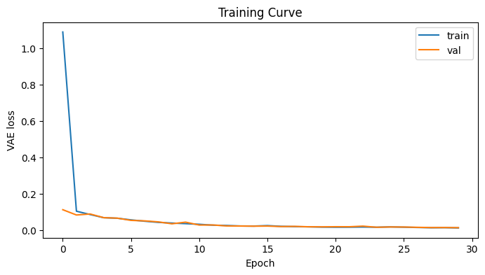

```python
class ConvVAE(nn.Module):
    def __init__(self, latent_dim=64):
        super().__init__()
        self.latent_dim = latent_dim

        # Input: [B, 1, 64, 128]
        self.encoder = nn.Sequential(
            nn.Conv2d(1, 32, kernel_size=4, stride=2, padding=1),   # [B, 32, 32, 64]
            nn.BatchNorm2d(32),
            nn.ReLU(),

            nn.Conv2d(32, 64, kernel_size=4, stride=2, padding=1),  # [B, 64, 16, 32]
            nn.BatchNorm2d(64),
            nn.ReLU(),

            nn.Conv2d(64, 128, kernel_size=4, stride=2, padding=1), # [B, 128, 8, 16]
            nn.BatchNorm2d(128),
            nn.ReLU(),

            nn.Conv2d(128, 256, kernel_size=4, stride=2, padding=1), # [B, 256, 4, 8]
            nn.BatchNorm2d(256),
            nn.ReLU(),
        )

        self.flatten_dim = 256 * 4 * 8

        self.fc_mu = nn.Linear(self.flatten_dim, latent_dim)
        self.fc_logvar = nn.Linear(self.flatten_dim, latent_dim)

        self.fc_decode = nn.Linear(latent_dim, self.flatten_dim)

        self.decoder = nn.Sequential(
            nn.ConvTranspose2d(256, 128, kernel_size=4, stride=2, padding=1), # [B, 128, 8, 16]
            nn.BatchNorm2d(128),
            nn.ReLU(),

            nn.ConvTranspose2d(128, 64, kernel_size=4, stride=2, padding=1),  # [B, 64, 16, 32]
            nn.BatchNorm2d(64),
            nn.ReLU(),

            nn.ConvTranspose2d(64, 32, kernel_size=4, stride=2, padding=1),   # [B, 32, 32, 64]
            nn.BatchNorm2d(32),
            nn.ReLU(),

            nn.ConvTranspose2d(32, 1, kernel_size=4, stride=2, padding=1),    # [B, 1, 64, 128]
            nn.Tanh(),
        )

    def encode(self, x):
        h = self.encoder(x)
        h = h.view(h.size(0), -1)
        mu = self.fc_mu(h)
        logvar = self.fc_logvar(h)
        return mu, logvar

    def reparameterize(self, mu, logvar):
        std = torch.exp(0.5 * logvar)
        eps = torch.randn_like(std)
        return mu + eps * std

    def decode(self, z):
        h = self.fc_decode(z)
        h = h.view(z.size(0), 256, 4, 8)
        return self.decoder(h)

    def forward(self, x):
        mu, logvar = self.encode(x)
        z = self.reparameterize(mu, logvar)
        recon = self.decode(z)
        return recon, mu, logvar

def vae_loss(recon, x, mu, logvar, beta=0.001):
    recon_loss = F.mse_loss(recon, x, reduction="mean")
    kl_loss = -0.5 * torch.mean(1 + logvar - mu.pow(2) - logvar.exp())
    total = recon_loss + beta * kl_loss
    return total, recon_loss, kl_loss


model = ConvVAE(latent_dim=LATENT_DIM).to(device)
optimizer = torch.optim.Adam(model.parameters(), lr=LR)

history = {
    "train_loss": [],
    "val_loss": [],
    "train_recon": [],
    "val_recon": [],
    "train_kl": [],
    "val_kl": [],
}

for epoch in range(EPOCHS):
    model.train()

    train_loss = train_recon = train_kl = 0.0

    for specs, _ in train_loader:
        specs = specs.to(device)

        optimizer.zero_grad()
        recon, mu, logvar = model(specs)
        loss, recon_loss, kl_loss = vae_loss(recon, specs, mu, logvar, beta=BETA)

        loss.backward()
        optimizer.step()

        train_loss += loss.item()
        train_recon += recon_loss.item()
        train_kl += kl_loss.item()

    train_loss /= len(train_loader)
    train_recon /= len(train_loader)
    train_kl /= len(train_loader)

    model.eval()
    val_loss = val_recon = val_kl = 0.0

    with torch.no_grad():
        for specs, _ in val_loader:
            specs = specs.to(device)
            recon, mu, logvar = model(specs)
            loss, recon_loss, kl_loss = vae_loss(recon, specs, mu, logvar, beta=BETA)

            val_loss += loss.item()
            val_recon += recon_loss.item()
            val_kl += kl_loss.item()

    val_loss /= len(val_loader)
    val_recon /= len(val_loader)
    val_kl /= len(val_loader)

    history["train_loss"].append(train_loss)
    history["val_loss"].append(val_loss)
    history["train_recon"].append(train_recon)
    history["val_recon"].append(val_recon)
    history["train_kl"].append(train_kl)
    history["val_kl"].append(val_kl)

    print(
        f"Epoch {epoch+1:03d} | "
        f"train loss {train_loss:.4f} | val loss {val_loss:.4f} | "
        f"train recon {train_recon:.4f} | val recon {val_recon:.4f} | "
        f"KL {val_kl:.4f}"
    )

plt.figure(figsize=(8, 4))
plt.plot(history["train_loss"], label="train")
plt.plot(history["val_loss"], label="val")
plt.xlabel("Epoch")
plt.ylabel("VAE loss")
plt.legend()
plt.title("Training Curve")
plt.show()
```

**Step 7:** Produce outputs

Here, we first try to reconstruct a single spectrogram accurately to see if the encoder and decoder work together properly. Then, we generate random vectors in the encoding space and send them through the decoder, allowing us to generate entirely new audio clips from scratch. Finally, we convert these spectrograms back to audio clips and save them.

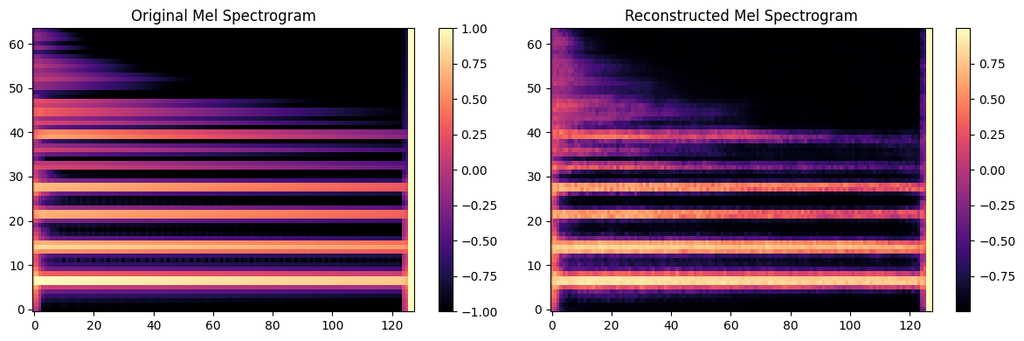

```
Saved generated clips to outputs/vae_samples
```

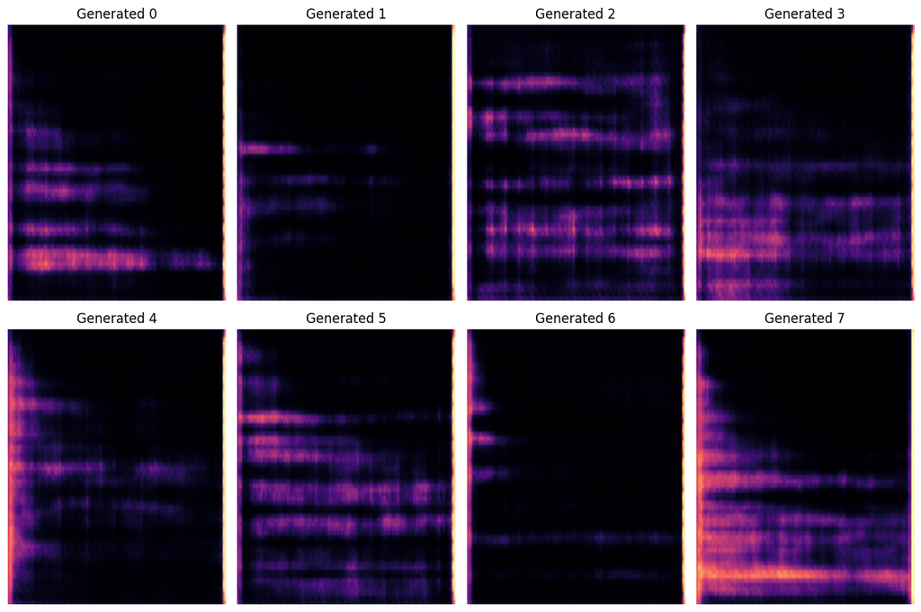

```python
def denormalize_mel(mel_norm):
    # Inverse of: mel_norm = (mel_db + 40) / 40
    return mel_norm * 40.0 - 40.0


def mel_norm_to_audio(mel_norm, out_path=None):
    """
    mel_norm shape: [64, 128], values in [-1, 1]
    """
    mel_db = denormalize_mel(mel_norm)
    mel_power = librosa.db_to_power(mel_db)

    audio = librosa.feature.inverse.mel_to_audio(
        mel_power,
        sr=SR,
        n_fft=N_FFT,
        hop_length=HOP_LENGTH,
        n_iter=64,
        power=2.0,
    )

    if out_path is not None:
        sf.write(out_path, audio, SR)

    return audio

model.eval()

specs, names = next(iter(val_loader))
specs = specs.to(device)

with torch.no_grad():
    recon, mu, logvar = model(specs)

# Take first example
original = specs[0, 0].cpu().numpy()
reconstructed = recon[0, 0].cpu().numpy()

plt.figure(figsize=(12, 4))

plt.subplot(1, 2, 1)
plt.imshow(original, origin="lower", aspect="auto", cmap="magma")
plt.title("Original Mel Spectrogram")
plt.colorbar()

plt.subplot(1, 2, 2)
plt.imshow(reconstructed, origin="lower", aspect="auto", cmap="magma")
plt.title("Reconstructed Mel Spectrogram")
plt.colorbar()

plt.tight_layout()
plt.show()

# Save original-ish audio from original mel and reconstructed audio
mel_norm_to_audio(original, SAMPLE_DIR / "reconstruction_original_mel.wav")
mel_norm_to_audio(reconstructed, SAMPLE_DIR / "reconstruction_vae.wav")

model.eval()

num_samples = 8

with torch.no_grad():
    z = torch.randn(num_samples, LATENT_DIM).to(device)
    generated = model.decode(z).cpu()

for i in range(num_samples):
    mel_norm = generated[i, 0].numpy()
    out_path = SAMPLE_DIR / f"generated_{i:02d}.wav"
    mel_norm_to_audio(mel_norm, out_path)

print(f"Saved generated clips to {SAMPLE_DIR}")

# Visualize generated spectrograms
plt.figure(figsize=(12, 8))

for i in range(min(num_samples, 8)):
    plt.subplot(2, 4, i + 1)
    plt.imshow(generated[i, 0].numpy(), origin="lower", aspect="auto", cmap="magma")
    plt.title(f"Generated {i}")
    plt.axis("off")

plt.tight_layout()
plt.show()

torch.save(
    {
        "model_state_dict": model.state_dict(),
        "latent_dim": LATENT_DIM,
        "history": history,
    },
    "outputs/vae_guitar_mel.pt",
)
```